# KHOA MÁY TÍNH

TRUONG_DUC_AN

10/22/2024

## ĐỀ TÀI:

# TIỀN XỬ LÝ SỐ LIỆU:

1. Đọc dữ liệu:

Đọc tệp tin GPU_data, in kết quả 6 dòng đầu tiên:

```r
# Đọc dữ liệu từ file CSV có tên "All_GPUs.csv" trên Desktop
GPU_data <- read.csv("~/Desktop/All_GPUs.csv")

# Hiển thị 6 dòng đầu tiên của dữ liệu đã đọc
head(GPU_data)
```

```
##   Architecture Best_Resolution Boost_Clock Core_Speed DVI_Connection Dedicated
## 1  Tesla G92b                                 738 MHz              2       Yes
## 2     R600 XT       1366 x 768                   \n-               2       Yes
## 3    R600 PRO       1366 x 768                   \n-               2       Yes
## 4       RV630       1024 x 768                   \n-               2       Yes
## 5       RV630       1024 x 768                   \n-               2       Yes
## 6       RV630       1024 x 768                   \n-               2       Yes
##   Direct_X DisplayPort_Connection HDMI_Connection Integrated L2_Cache
## 1  DX 10.0                     NA               0         No      0KB
## 2    DX 10                     NA               0         No      0KB
## 3    DX 10                     NA               0         No      0KB
## 4    DX 10                     NA               0         No      0KB
## 5    DX 10                     NA               0         No      0KB
## 6    DX 10                     NA               0         No      0KB
##   Manufacturer Max_Power   Memory Memory_Bandwidth Memory_Bus Memory_Speed
```

[output cut: 34 more lines]

2. Kiểm tra dữ liệu khuyết trong tập tin.

Tìm các dòng trống (hàng có toàn bộ các giá trị là rỗng hoặc "") trong dữ liệu và chuyển chúng thành giá trị NA:

```r
# Thay thế tất cả các ô trống trong dữ liệu GPU_data bằng NA
GPU_data[GPU_data == ""] <- NA
```

Tìm các giá trị trong dataframe có định dạng - (các giá trị bắt đầu bằng ký tự xuống dòng theo sau là dấu -) và chuyển chúng thành NA. Ta sử dụnglệnh gsub() để thay thế “-” bằng NA trong toàn bộ dataframe.

```r
# Thay thế các giá trị có định dạng "\n-" bằng NA trong tất cả các cột của GPU_data
GPU_data[] <- lapply(GPU_data, function(x) gsub("^\\n- $", NA, x))

# Thay thế các chuỗi "NA" bằng NA
GPU_data[GPU_data == "NA"] <- NA
```

Giải thích thêm: Nếu gsub() không trực tiếp chuyển thành NA được do NA không phải là một chuỗi ký tự, nên ta chuyển thành “NA” trước rồi chuyển các chuỗi “NA” về NA.

Ta thực hiện thống kê số lượng và tỷ lệ dữ liệu khuyết ở các biến:

```r
# Tạo bảng thống kê số lượng và tỷ lệ dữ liệu khuyết
na_summary <- data.frame(
  Column = names(GPU_data),
  NA_Count = sapply(GPU_data, function(x) sum(is.na(x))),
  NA_Percentage = sapply(GPU_data, function(x) mean(is.na(x)) * 100)
)

# Hiển thị bảng thống kê
print(na_summary)
```

```
##                                        Column NA_Count NA_Percentage
## Architecture                     Architecture       62     1.8203171
## Best_Resolution               Best_Resolution      642    18.8490898
## Boost_Clock                       Boost_Clock     1960    57.5455079
## Core_Speed                         Core_Speed      907    26.6294774
## DVI_Connection                 DVI_Connection      750    22.0199648
## Dedicated                           Dedicated       14     0.4110393
## Direct_X                             Direct_X        6     0.1761597
## DisplayPort_Connection DisplayPort_Connection     2549    74.8385203
## HDMI_Connection               HDMI_Connection      763    22.4016442
## Integrated                         Integrated       14     0.4110393
## L2_Cache                             L2_Cache        0     0.0000000
## Manufacturer                     Manufacturer        0     0.0000000
## Max_Power                           Max_Power      625    18.3499706
## Memory                                 Memory      420    12.3311803
## Memory_Bandwidth             Memory_Bandwidth      121     3.5525543
## Memory_Bus                         Memory_Bus       62     1.8203171
## Memory_Speed                     Memory_Speed      105     3.0827951
## Memory_Type                       Memory_Type       56     1.6441574
## Name                                     Name        0     0.0000000
## Notebook_GPU                     Notebook_GPU        0     0.0000000
## Open_GL                               Open_GL       40     1.1743981
## PSU                                       PSU     1175    34.4979448
## Pixel_Rate                         Pixel_Rate      544    15.9718144
## Power_Connector               Power_Connector      709    20.8162067
## Process                               Process      463    13.5936583
## ROPs                                     ROPs      538    15.7956547
## Release_Date                     Release_Date        0     0.0000000
## Release_Price                   Release_Price     2850    83.6758661
## Resolution_WxH                 Resolution_WxH      195     5.7251908
## SLI_Crossfire                   SLI_Crossfire        0     0.0000000
## Shader                                 Shader      107     3.1415150
## TMUs                                     TMUs      538    15.7956547
## Texture_Rate                     Texture_Rate      544    15.9718144
## VGA_Connection                 VGA_Connection      758    22.2548444
```

Dựa trên kết quả thu được, ta thấy có nhiều biến chứa dữ liệu khuyết, để trực quan hơn, ta thực hiện vẽ đồ thị thể hiện tỷ lệ dữ liệu khuyết ở từng biến bằng cách sử dụng hàm ggplot2.

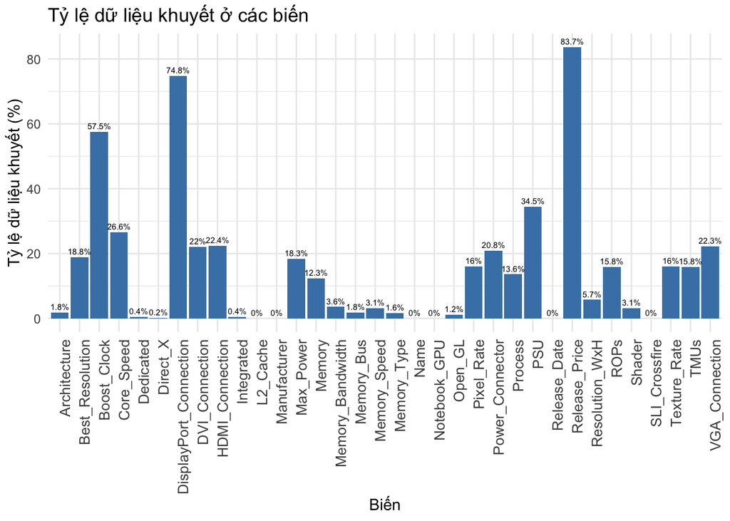

```r
# Gọi thư viện ggplot2 để sử dụng hàm ggplot
library(ggplot2)

# Tạo biểu đồ cột cho tỷ lệ dữ liệu khuyết ở các biến
ggplot(na_summary, aes(x = Column, y = NA_Percentage)) +
  geom_bar(stat = "identity", fill = "steelblue") +
  geom_text(aes(label = paste0(round(NA_Percentage, 1), "%")),
            vjust = -0.5, size = 2) +
  labs(title = "Tỷ lệ dữ liệu khuyết ở các biến",
       x = "Biến",
       y = "Tỷ lệ dữ liệu khuyết (%)") +
  theme_minimal() +
  theme(axis.text.x = element_text(size = 10, angle = 90, hjust = 1))
```

Ta thực hiện lọc bỏ các biến có tỷ lệ dữ liệu khuyết cao (>=10) và chỉ giữa lại các biến có dữ liệu khuyết dưới 10%. Ngoài ra, đối với các biến có dữ liệu khuyết dưới 10%, ta sẽ thực hiện xoá các quan sát chứa dữ liệu khuyết

```r
# Lọc các cột có tỷ lệ dữ liệu khuyết dưới 10%
selected_columns <- na_summary$Column[na_summary$NA_Percentage < 10]

# Giữ lại các cột thỏa mãn điều kiện trong dataframe ban đầu
new_GPU_data <- GPU_data[, selected_columns]

#Xoá các quan sát chứa dữ liệu khuyết
new_GPU_data<-na.omit(new_GPU_data)
```

3. Làm sạch các biến và xử lý định dạng các biến

Trong bộ dữ liệu có một vài biến “L2_Cache”,“Memory_Bandwidth”,“Memory_Bus”,“Memory_Speed” có chứa đơn vị, ta thực hiện loại bỏ các đơn vị của các biến này.

```r
# Lựa chọn các biến cần xoá đơn vị
columns_to_clean <- c("L2_Cache","Memory_Bandwidth","Memory_Bus","Memory_Speed")

#Tạo hàm thực hiện xoá đơn vị ở các biến
remove_units <- function(column) {
  # Sử dụng gsub để xóa tất cả các ký tự không phải số (kể cả đơn vị)
  cleaned_column <- gsub("[^0-9.]", "", column)
  # Chuyển đổi kết quả về kiểu numeric
  cleaned_column <- as.numeric(cleaned_column)

  return(cleaned_column)
}

# Áp dụng hàm cho các biến đã chọn
new_GPU_data[columns_to_clean] <- lapply(new_GPU_data[columns_to_clean], remove_units)
```

In 6 dòng đầu tiên của new_GPU_data sau khi làm sạch và kiểm tra số biến và số quan sát còn lại.

```r
head(new_GPU_data)
```

```
##   Architecture Dedicated Direct_X Integrated L2_Cache Manufacturer
## 1  Tesla G92b        Yes  DX 10.0         No        0       Nvidia
## 2     R600 XT        Yes    DX 10         No        0          AMD
## 3    R600 PRO        Yes    DX 10         No        0          AMD
## 4       RV630        Yes    DX 10         No        0          AMD
## 5       RV630        Yes    DX 10         No        0          AMD
## 6       RV630        Yes    DX 10         No        0          AMD
##   Memory_Bandwidth Memory_Bus Memory_Speed Memory_Type
## 1             64.0        256         1000       GDDR3
## 2            106.0        512          828       GDDR3
## 3             51.2        256          800       GDDR3
## 4             36.8        128         1150       GDDR4
## 5             22.4        128          700       GDDR3
## 6             35.2        128         1100       GDDR4
##                                Name Notebook_GPU Open_GL   Release_Date
## 1                   GeForce GTS 150           No     3.3 \n01-Mar-2009
## 2           Radeon HD 2900 XT 512MB           No     3.1 \n14-May-2007
## 3                Radeon HD 2900 Pro           No     3.1 \n07-Dec-2007
## 4 Radeon HD 2600 XT Diamond Edition           No     3.3 \n01-Jul-2007
## 5                 Radeon HD 2600 XT           No     3.1 \n28-Jun-2007
## 6     Radeon HD 2600 XT 256MB GDDR4           No     3.3 \n26-Jun-2007
##   Resolution_WxH SLI_Crossfire Shader
## 1      2560x1600           Yes      4
## 2      2560x1600           Yes      4
## 3      2560x1600           Yes      4
## 4      2560x1600           Yes      4
## 5      2560x1600           Yes      4
## 6      2560x1600           Yes      4
```

```r
dim(new_GPU_data)
```

```
## [1] 3036   17
```

Sau khi làm sạch bộ dữ liệu, dữ liệu còn lại 17 biến và 3036 quan sát, ta tiếp tục thực hiện chọn lọc các biến quan trọng, và ta nhận thấy Memory_Bandwidth là một thông số quan trọng để đánh giá hiệu suất GPUs.

Và mô hình Hồi quy là lựa chọn phù hợp và đơn giản nhất cho việc phân tích những nhân tố ảnh hưởng đến Memory_Bandwidth.

Khi xây dựng mô hình hồi quy với Memory_Bandwidth là biến phụ thuộc, ta xem xét các biến độc lập (sau khi đã làm sạch dữ liệu): Memory_Speed, L2_Cache, Architecture, Dedicated, Memory_Bus, Shader, Direct_X và Resolution_WxH.

Tuy nhiên vì các biến Architecture, Direct_X, Resolution_WxH là các biến dạng chuỗi và nhận nhiều giá trị, và việc đưa các biến này vào mô hình hồi quy sẽ rất khó khăn cho việc phân tích nên do đó, ta sẽ lựa chọn các biến độc lập Memory_Speed, L2_Cache, Dedicated, Memory_Bus, Shade, và ngoài ra ta sẽ đưa thêm biến Manufacturer vào bài phân tích để so sánh tốc độ Memory_Bandwidth ở các GPU ở các nhà sản xuất.

4. Tạo bộ dữ liệu bao gồm các biến chính để phân tích.

```r
main_data<-new_GPU_data[c("Memory_Bandwidth","Memory_Speed","L2_Cache","Memory_Bus","Shader","Dedicated","Manufacturer")]
head(main_data)
```

```
##   Memory_Bandwidth Memory_Speed L2_Cache Memory_Bus Shader Dedicated
## 1             64.0         1000        0        256      4       Yes
## 2            106.0          828        0        512      4       Yes
## 3             51.2          800        0        256      4       Yes
## 4             36.8         1150        0        128      4       Yes
## 5             22.4          700        0        128      4       Yes
## 6             35.2         1100        0        128      4       Yes
##   Manufacturer
## 1       Nvidia
## 2          AMD
## 3          AMD
## 4          AMD
## 5          AMD
## 6          AMD
```

# THỐNG KÊ MÔ TẢ

Đối với các biến định lượng (liên tục và rời rạc), ta thực hiện tính thống kê mô tả bao gồm trung bình, độ lệch chuẩn mẫu, các phân vị, trung vị, giá trị lớn nhất và giá trị nhỏ nhất.

```r
# Xác định các biến số và tạo một khung dữ liệu chỉ chứa các biến số
new_numeric_vars <- sapply(main_data, is.numeric)
numeric_data <- main_data[, new_numeric_vars]

# Tính toán các thống kê mô tả cho các biến số
summary_stats <- sapply(numeric_data, function(x) {
  c(
    Mean = mean(x),                   # Trung bình
    SD = sd(x),                       # Độ lệch chuẩn
    Min = min(x),                     # Giá trị nhỏ nhất
    Q1 = quantile(x, 0.25),           # Phân vị 25%
    Median = median(x),               # Trung vị
    Q3 = quantile(x, 0.75),           # Phân vị 75%
    Max = max(x)                      # Giá trị lớn nhất
  )
})

# Chuyển thống kê mô tả thành dataframe và xuất ra dưới dạng bảng
t(as.data.frame(summary_stats))
```

```
##                       Mean        SD Min Q1.25% Median  Q3.75%   Max
## Memory_Bandwidth  144.7002  135.4090   2     32  112.1  223.85  1280
## Memory_Speed     1211.1077  420.2349 200    900 1247.5 1502.00  2127
## L2_Cache         1335.0817 3209.3938   0    128  512.0 1024.00 30722
## Memory_Bus        210.6746  221.9971  32    128  128.0  256.00  4096
```

Đối với các biến phân loại, ta lập bảng thống kê số lượng cho các phân loại.

```r
# Thống kê số lượng cho biến Manufacturer
table(main_data$Manufacturer)
```

```
##
##    AMD    ATI  Intel Nvidia
##   1161     82    152   1641
```

```r
# Thống kê số lượng cho biến Dedicated
table(main_data$Dedicated)
```

```
##
##   No  Yes
##  214 2822
```

```r
# Thống kê số lượng cho biến Shader
table(main_data$Shader)
```

```
##
##    1  1.4    2    3    4  4.1    5
##    1    7   39   82  194  126 2587
```

Vẽ đồ thị hist cho biến Memory_Bandwidth bằng đồ thị ggplot

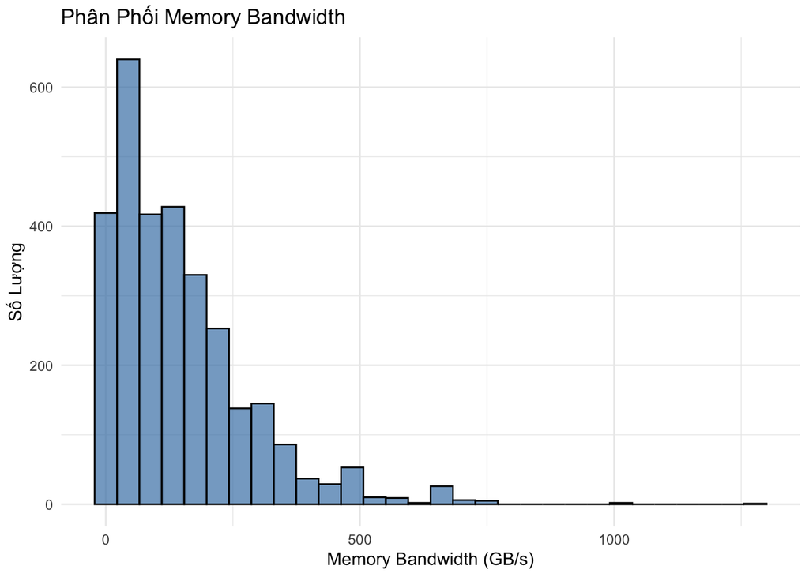

```r
# Vẽ histogram cho biến Memory_Bandwidth
ggplot(main_data, aes(x = Memory_Bandwidth)) +
  geom_histogram(fill = "steelblue", color = "black",alpha = 0.7) +  # Thay đổi binwidth theo yêu cầu
  labs(title = "Phân Phối Memory Bandwidth",
       x = "Memory Bandwidth (GB/s)",  # Ghi chú đơn vị nếu cần
       y = "Số Lượng") +
  theme_minimal()
```

Vẽ đồ thị boxplot cho biến Memory_Bandwidth theo Manufacturer, Dedicated

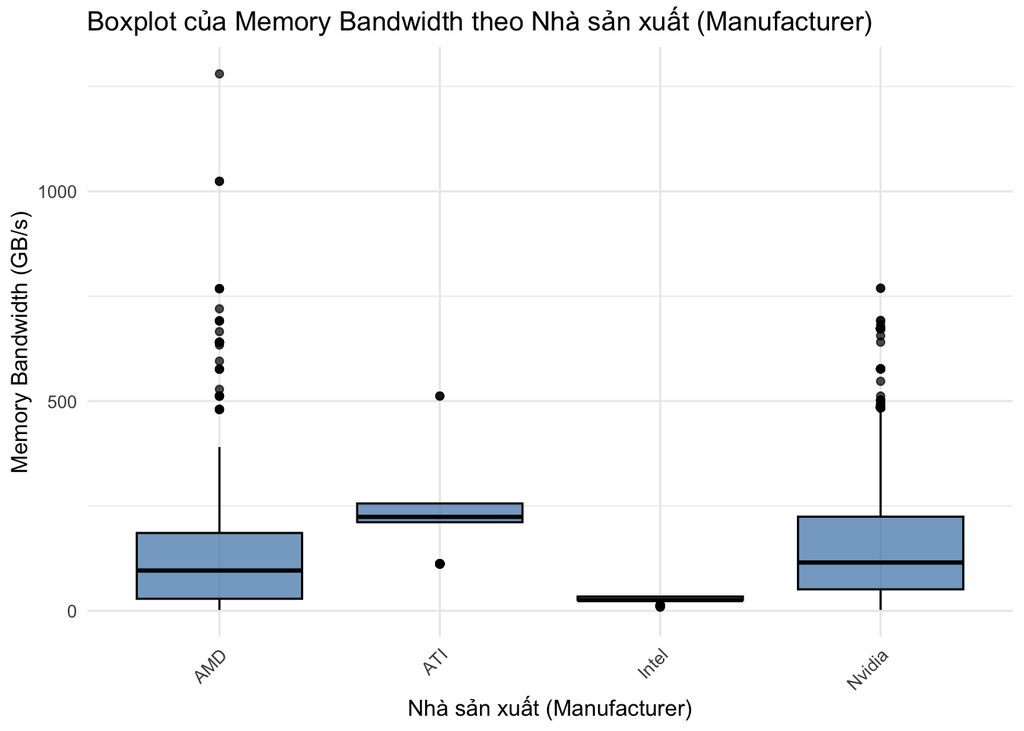

```r
# Vẽ boxplot cho Memory_Bandwidth theo Manufacturer
ggplot(main_data, aes(x = Manufacturer, y = Memory_Bandwidth)) +
  geom_boxplot(fill = "steelblue", color = "black", alpha = 0.7) +  # Thay đổi màu sắc và độ trong suốt của hộp
  labs(title = "Boxplot của Memory Bandwidth theo Nhà sản xuất (Manufacturer)",
       x = "Nhà sản xuất (Manufacturer)",
       y = "Memory Bandwidth (GB/s)") +
  theme_minimal() +
  theme(axis.text.x = element_text(angle = 45, hjust = 1))  # Xoay nhãn trục x để dễ đọc hơn
```

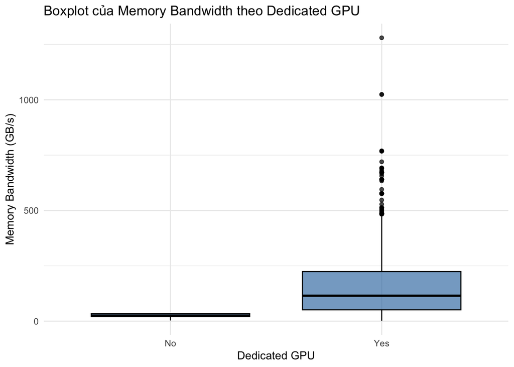

```r
# Vẽ boxplot cho Memory_Bandwidth theo Dedicated
ggplot(main_data, aes(x = Dedicated, y = Memory_Bandwidth)) +
  geom_boxplot(fill = "steelblue", color = "black", alpha = 0.7) +  # Thay đổi màu sắc và độ trong suốt của hộp
  labs(title = "Boxplot của Memory Bandwidth theo Dedicated GPU",
       x = "Dedicated GPU",
       y = "Memory Bandwidth (GB/s)") +
  theme_minimal() +
  theme(axis.text.x = element_text(angle = 0, hjust = 0.5))  # Điều chỉnh vị trí nhãn trục x
```

Dựa trên đồ thị, GPU rời thường có hiệu suất xử lý đồ họa cao hơn, ảnh hưởng đến trải nghiệm người dùng trong game và ứng dụng đồ họa.

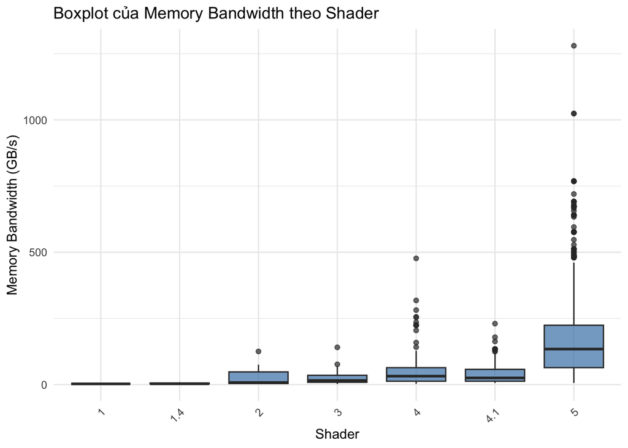

```r
# Vẽ boxplot cho Memory_Bandwidth theo Shader
ggplot(main_data, aes(x = Shader, y = Memory_Bandwidth)) +
  geom_boxplot(fill = "steelblue", alpha = 0.7) +  # Thay đổi màu sắc và độ trong suốt
  labs(title = "Boxplot của Memory Bandwidth theo Shader",
       x = "Shader",
       y = "Memory Bandwidth (GB/s)") +
  theme_minimal() +
  theme(axis.text.x = element_text(angle = 45, hjust = 1))  # Xoay nhãn trục x
```

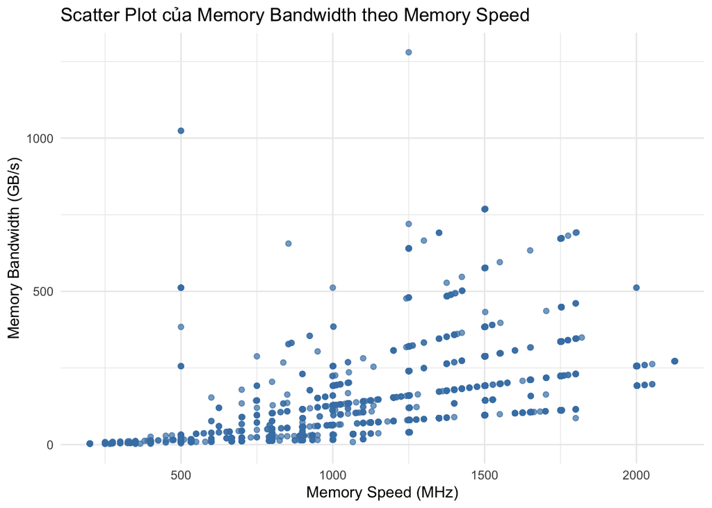

```r
# Vẽ scatter plot cho Memory_Bandwidth theo Memory_Speed
ggplot(main_data, aes(x = Memory_Speed, y = Memory_Bandwidth)) +
  geom_point(color = "steelblue", alpha = 0.7) +  # Thay đổi màu sắc và độ trong suốt của điểm
  labs(title = "Scatter Plot của Memory Bandwidth theo Memory Speed",
       x = "Memory Speed (MHz)",
       y = "Memory Bandwidth (GB/s)") +
  theme_minimal()
```

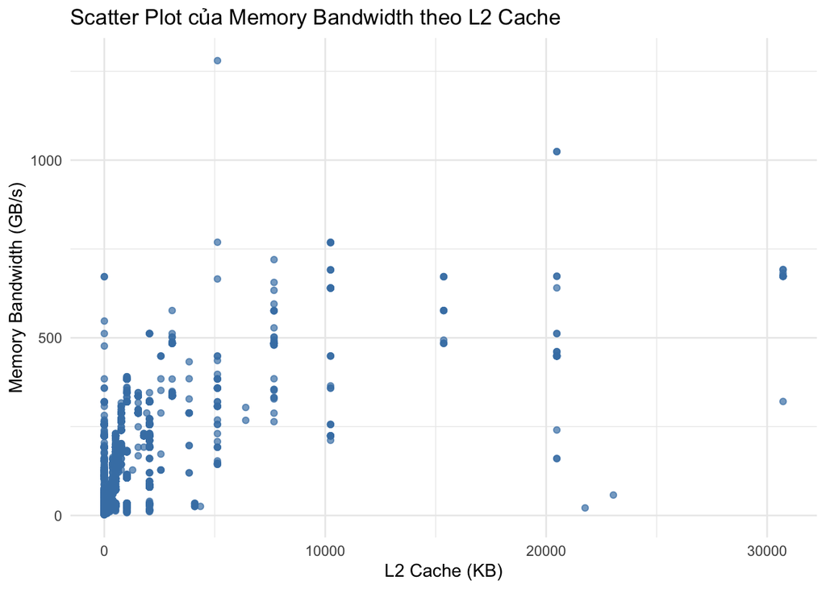

```r
# Vẽ scatter plot cho Memory_Bandwidth theo L2_Cache
ggplot(main_data, aes(x = L2_Cache, y = Memory_Bandwidth)) +
  geom_point(color = "steelblue", alpha = 0.7) +  # Thay đổi màu sắc và độ trong suốt của điểm
  labs(title = "Scatter Plot của Memory Bandwidth theo L2 Cache",
       x = "L2 Cache (KB)",
       y = "Memory Bandwidth (GB/s)") +
  theme_minimal()
```

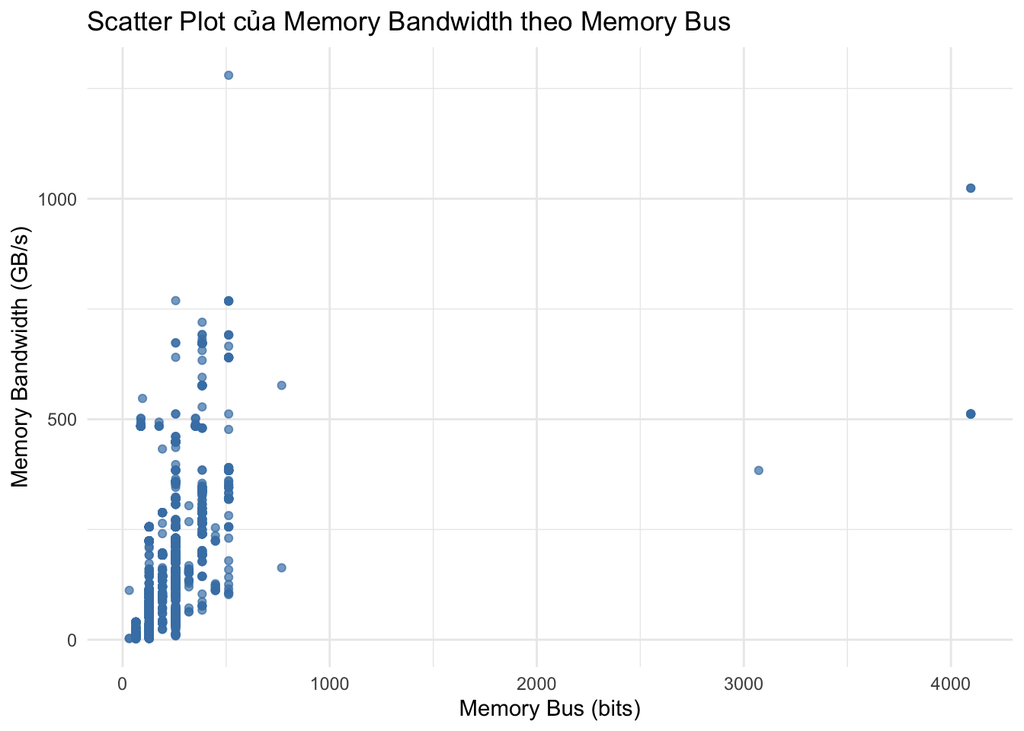

```r
# Vẽ scatter plot cho Memory_Bandwidth theo Memory_Bus
ggplot(main_data, aes(x = Memory_Bus, y = Memory_Bandwidth)) +
  geom_point(color = "steelblue", alpha = 0.7) +  # Thay đổi màu sắc và độ trong suốt của điểm
  labs(title = "Scatter Plot của Memory Bandwidth theo Memory Bus",
       x = "Memory Bus (bits)",
       y = "Memory Bandwidth (GB/s)") +
  theme_minimal()
```

# THỐNG KÊ SUY DIỄN

1. Chia tập dữ liệu thành 2 phần train_data và test_data theo tỷ lệ 7:3. Tập train_data dùng để xây dựng mô hình và tập test_data dùng để thực hiện dự báo.

```r
library(caret)
# Giả sử bạn có một biến mục tiêu là 'Memory_Bandwidth'
set.seed(123)  # Đặt seed để tái lập kết quả
train_index <- createDataPartition(main_data$Memory_Bandwidth, p = 0.7, list = FALSE)

# Tập huấn luyện
train_data <- main_data[train_index, ]

# Tập kiểm tra
test_data <- main_data[-train_index, ]

# Kiểm tra kích thước của các tập
dim(train_data)
```

```
## [1] 2127    7
```

```r
dim(test_data)
```

```
## [1] 909   7
```

2. Thực hiện xây dựng mô hình dự trên tập train_data:

```r
# Xây dựng mô hình hồi quy tuyến tính
model <- lm(Memory_Bandwidth ~ Memory_Speed + L2_Cache + Memory_Bus, data = train_data)

# Xem tóm tắt của mô hình
summary(model)
```

```
##
## Call:
## lm(formula = Memory_Bandwidth ~ Memory_Speed + L2_Cache + Memory_Bus,
##     data = train_data)
##
## Residuals:
##     Min      1Q  Median      3Q     Max
## -415.08  -33.90  -13.58   19.06  506.40
##
## Coefficients:
##                Estimate Std. Error t value Pr(>|t|)
## (Intercept)  -9.616e+01  5.048e+00  -19.05   <2e-16 ***
## Memory_Speed  1.408e-01  3.921e-03   35.90   <2e-16 ***
## L2_Cache      1.799e-02  5.108e-04   35.22   <2e-16 ***
## Memory_Bus    2.153e-01  6.934e-03   31.05   <2e-16 ***
## ---
## Signif. codes:  0 '***' 0.001 '**' 0.01 '*' 0.05 '.' 0.1 ' ' 1
##
## Residual standard error: 73.49 on 2123 degrees of freedom
## Multiple R-squared:  0.6986, Adjusted R-squared:  0.6982
## F-statistic:  1640 on 3 and 2123 DF,  p-value: < 2.2e-16
```

Ta vẽ đồ thị phần dư bằng lệnh này sẽ tạo ra 4 đồ thị để kiểm tra mô hình:

Đồ thị 1 - Residuals vs Fitted: Kiểm tra tính đồng nhất phương sai. Nếu phần dư phân bố ngẫu nhiên quanh đường zero, giả định đồng nhất phương sai được thỏa mãn.

Đồ thị 2 - Normal Q-Q: Kiểm tra phần dư có phân phối chuẩn hay không. Các điểm nên nằm gần đường thẳng.

Đồ thị 3 - Scale-Location: Cũng kiểm tra tính đồng nhất phương sai. Đồ thị này giúp xác định xem phương sai của phần dư có ổn định không.

Đồ thị 4 -Residuals vs Leverage: Giúp xác định điểm ảnh hưởng mạnh (outliers) trong dữ liệu.

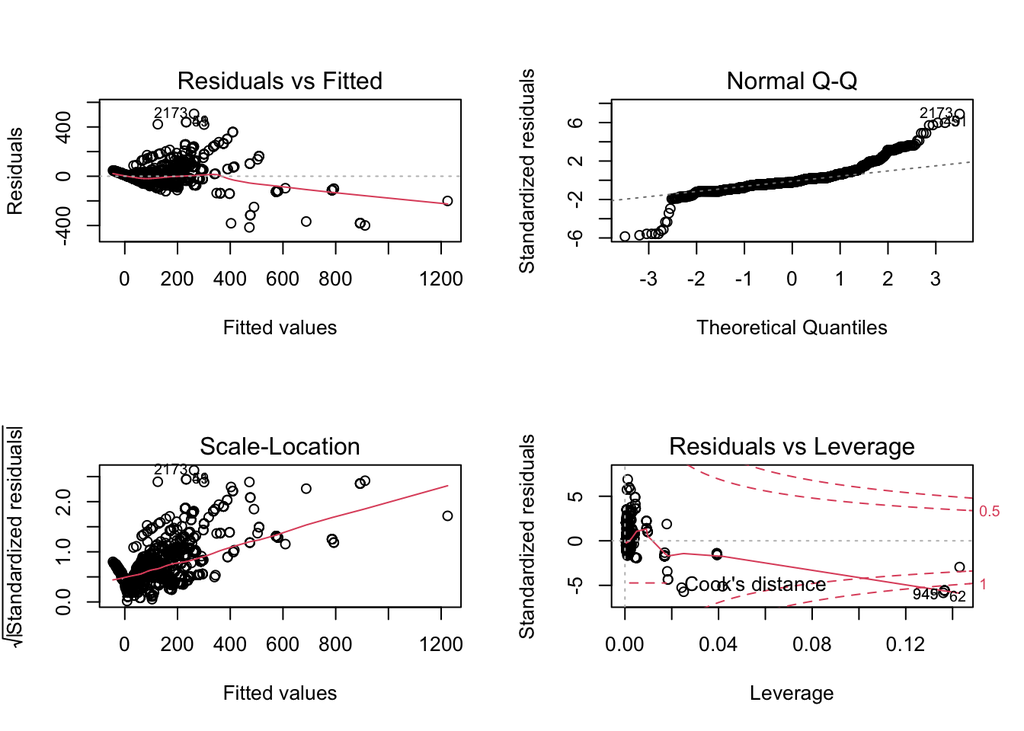

```r
# Kiểm tra các phần dư
par(mfrow = c(2, 2))  # Chia bố cục đồ thị thành 2x2
plot(model)
```

Để kiểm tra hiện tượng đa cộng tuyến (Multicollinearity) giữa các biến độc lập: ta thực hiện tính hệ số VIF (Variance Inflation Factor) để kiểm tra đa cộng tuyến giữa các biến độc lập. Nếu giá trị VIF của một biến vượt quá 5 hoặc 10, có thể có đa cộng tuyến giữa biến đó và các biến khác.

```r
# Nạp thư viện car để tính VIF
library(car)
# Tính VIF cho các biến độc lập
vif(model)
```

```
## Memory_Speed     L2_Cache   Memory_Bus
##     1.069013     1.091148     1.025577
```

Ngoài ra, ta có thể sử dụng hist() và qqnorm() để kiểm tra phân phối chuẩn của phần dư

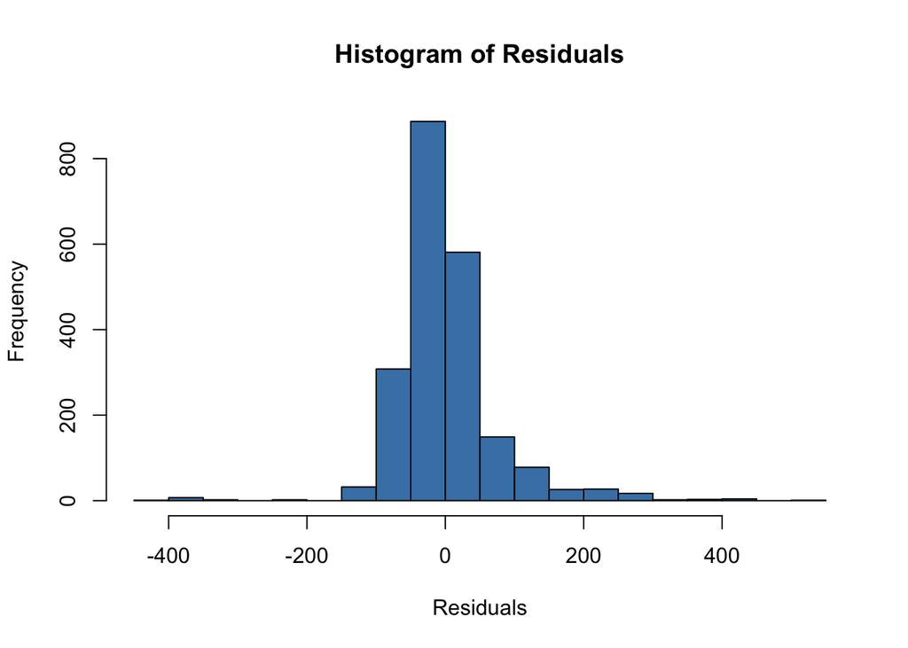

```r
# Vẽ histogram của phần dư
hist(residuals(model), breaks = 20, main = "Histogram of Residuals",
     xlab = "Residuals", col = "steelblue")
```

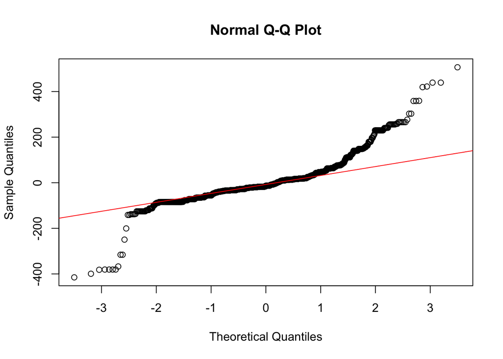

```r
# Vẽ Q-Q plot của phần dư
qqnorm(residuals(model))
qqline(residuals(model), col = "red")
```

4. Thực hiện dự đoán dựa trên tập kiểm tra:

```r
# Dự đoán trên tập kiểm tra
predictions <- predict(model, newdata = test_data)

# Thêm dự đoán vào tập kiểm tra
test_data$Predicted_Memory_Bandwidth <- predictions

# Xem một vài dự đoán
head(test_data)
```

```
##    Memory_Bandwidth Memory_Speed L2_Cache Memory_Bus Shader Dedicated
## 5              22.4          700        0        128      4       Yes
## 7             134.4         1050        0        256    4.1       Yes
## 9             160.0         1250        0        256      5       Yes
## 10              2.9          366        0         64      1       Yes
## 12            177.6          925      768        384      5       Yes
## 20             23.4          730        0        256      2       Yes
##    Manufacturer Predicted_Memory_Bandwidth
## 5           AMD                   29.94128
## 7           AMD                  106.76897
## 9           AMD                  134.92527
## 10          AMD                  -30.85682
## 12       Nvidia                  130.54362
## 20          AMD                   61.71889
```

5. Đánh giá mô hình :

```r
# Tính RMSE
rmse <- sqrt(mean((test_data$Memory_Bandwidth - test_data$Predicted_Memory_Bandwidth)^2))
print(paste("RMSE:", rmse))
```

```
## [1] "RMSE: 77.2747328046004"
```

```r
# Tính R-squared
r_squared <- 1 - (sum((test_data$Memory_Bandwidth - test_data$Predicted_Memory_Bandwidth)^2) /
                   sum((test_data$Memory_Bandwidth - mean(test_data$Memory_Bandwidth))^2))
print(paste("R-squared:", r_squared))
```

```
## [1] "R-squared: 0.691775650625235"
```

Nhận xét:

Mô hình hồi quy có mức độ dự đoán tương đối tốt với R² = 0.692, tức là mô hình có thể giải thích được phần lớn sự biến động của Memory_Bandwidth.

Tuy nhiên, RMSE = 77.27 cho thấy vẫn còn sai số trong dự đoán. Mức độ này có thể chấp nhận được hoặc không, tùy thuộc vào đặc điểm của dữ liệu thực tế.

Đề xuất: để cải thiện mô hình, bạn có thể:

- Thử nghiệm với các biến độc lập khác.
- Xem xét khả năng thêm vào hoặc loại bỏ các biến ít có ý nghĩa.
- Sử dụng các mô hình phức tạp hơn như hồi quy đa thức hoặc các mô hình phi tuyến tính nếu cần thiết.